## Project: Machine Learning

by Daniela Galatro, March 2019

### Background

Using devices such as Jawbone Up, Nike FuelBand, and Fitbit it is now possible to collect a large amount of data about personal activity relatively inexpensively. These type of devices are part of the quantified self movement - a group of enthusiasts who take measurements about themselves regularly to improve their health, to find patterns in their behavior, or because they are tech geeks. One thing that people regularly do is quantify how much of a particular activity they do, but they rarely quantify how well they do it. In this project, your goal will be to use data from accelerometers on the belt, forearm, arm, and dumbell of 6 participants. They were asked to perform barbell lifts correctly and incorrectly in 5 different ways. More information is available from the website here: http://groupware.les.inf.puc-rio.br/har (see the section on the Weight Lifting Exercise Dataset).

### Objective

The goal of your project is to predict the manner in which they did the exercise. This is the “classe” variable in the training set. You may use any of the other variables to predict with. You should create a report describing how you built your model, how you used cross validation, what you think the expected out of sample error is, and why you made the choices you did. You will also use your prediction model to predict 20 different test cases.

### Libraries

```r
library(gbm)
library(caret)
library(rattle)
library(randomForest)
```

```r
library(rpart.plot)
```

### Exploratory Data Analysis and Data Preparation

#### Getting the data

The training data for this project are available here: https://d396qusza40orc.cloudfront.net/predmachlearn/pml-training.csv

The test data are available here: https://d396qusza40orc.cloudfront.net/predmachlearn/pml-testing.csv

The data for this project come from this source: http://groupware.les.inf.puc-rio.br/har.

```r
train_in <- read.csv('./pml-training.csv', header=T)
valid_in <- read.csv('./pml-testing.csv', header=T)
dim(train_in)
```

```
## [1] 19622   160
```

```r
dim(valid_in)
```

```
## [1]  20 160
```

#### Cleaning the data

```r
trainData<- train_in[, colSums(is.na(train_in)) == 0]
validData <- valid_in[, colSums(is.na(valid_in)) == 0]
dim(trainData)
```

```
## [1] 19622    93
```

```r
dim(validData)
```

```
## [1] 20 60
```

Removing first seven variables

```r
trainData <- trainData[, -c(1:7)]
validData <- validData[, -c(1:7)]
dim(trainData)
```

```
## [1] 19622    86
```

```r
dim(validData)
```

```
## [1] 20 53
```

#### Data preparation for prediction

```r
set.seed(1234)
inTrain <- createDataPartition(trainData$classe, p = 0.7, list = FALSE)
trainData <- trainData[inTrain, ]
testData <- trainData[-inTrain, ]
#Further cleaning by removing variables with near-zero variance
NZV <- nearZeroVar(trainData)
trainData <- trainData[, -NZV]
testData  <- testData[, -NZV]
dim(trainData)
```

```
## [1] 13737    53
```

```r
dim(testData)
```

```
## [1] 4124   53
```

### Model Building

##### Classification trees

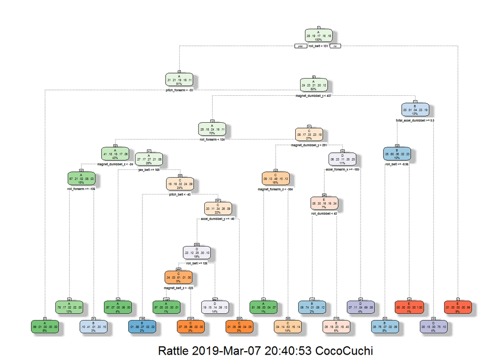

```r
set.seed(12345)
decisionTreeMod1 <- rpart(classe ~ ., data=trainData, method="class")
fancyRpartPlot(decisionTreeMod1)
```

Prediction and confusion matrix:

```r
prediction1 <-predict(decisionTreeMod1, testData, type = "class")
summary(prediction1)
```

```
##    A    B    C    D    E
## 1156  576  863  888  641
```

```r
confMatrix <- confusionMatrix(prediction1, testData$classe)
confMatrix
```

```
## Confusion Matrix and Statistics
##
##           Reference
## Prediction   A   B   C   D   E
##          A 990 121  15  23   7
##          B  32 402  31  56  55
##          C  22  94 540 129  78
##          D 120 142  74 437 115
##          E  12  40  51  34 504
##
## Overall Statistics
##
##                Accuracy : 0.6967
##                  95% CI : (0.6824, 0.7107)
##     No Information Rate : 0.2852
##     P-Value [Acc > NIR] : < 2.2e-16
##
##                   Kappa : 0.6174
##  Mcnemar's Test P-Value : < 2.2e-16
##
## Statistics by Class:
##
##                      Class: A Class: B Class: C Class: D Class: E
## Sensitivity            0.8418  0.50313   0.7595   0.6436   0.6640
## Specificity            0.9437  0.94767   0.9054   0.8691   0.9593
## Pos Pred Value         0.8564  0.69792   0.6257   0.4921   0.7863
## Neg Pred Value         0.9373  0.88811   0.9476   0.9252   0.9268
## Prevalence             0.2852  0.19374   0.1724   0.1646   0.1840
## Detection Rate         0.2401  0.09748   0.1309   0.1060   0.1222
## Detection Prevalence   0.2803  0.13967   0.2093   0.2153   0.1554
## Balanced Accuracy      0.8928  0.72540   0.8324   0.7563   0.8117
```

Plot:

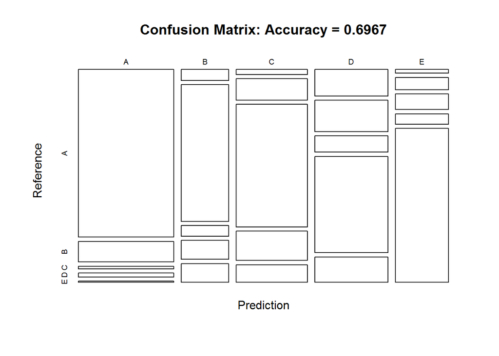

```r
plot(confMatrix$table, col = confMatrix$byClass, main = paste("Confusion Matrix: Accuracy =", round(confMatrix$overall['Accuracy'], 4)))
```

##### Random Forest

```r
set.seed(10000)
modelfit2 <- randomForest(classe ~ ., data=trainData)
prediction2 <- predict(modelfit2, testData, type = "class")
confMatrix2 <- confusionMatrix(prediction2, testData$classe)
confMatrix2
```

```
## Confusion Matrix and Statistics
##
##           Reference
## Prediction    A    B    C    D    E
##          A 1176    0    0    0    0
##          B    0  799    0    0    0
##          C    0    0  711    0    0
##          D    0    0    0  679    0
##          E    0    0    0    0  759
##
## Overall Statistics
##
##                Accuracy : 1
##                  95% CI : (0.9991, 1)
##     No Information Rate : 0.2852
##     P-Value [Acc > NIR] : < 2.2e-16
##
##                   Kappa : 1
##  Mcnemar's Test P-Value : NA
##
## Statistics by Class:
##
##                      Class: A Class: B Class: C Class: D Class: E
## Sensitivity            1.0000   1.0000   1.0000   1.0000    1.000
## Specificity            1.0000   1.0000   1.0000   1.0000    1.000
## Pos Pred Value         1.0000   1.0000   1.0000   1.0000    1.000
## Neg Pred Value         1.0000   1.0000   1.0000   1.0000    1.000
## Prevalence             0.2852   0.1937   0.1724   0.1646    0.184
## Detection Rate         0.2852   0.1937   0.1724   0.1646    0.184
## Detection Prevalence   0.2852   0.1937   0.1724   0.1646    0.184
## Balanced Accuracy      1.0000   1.0000   1.0000   1.0000    1.000
```

Plot:

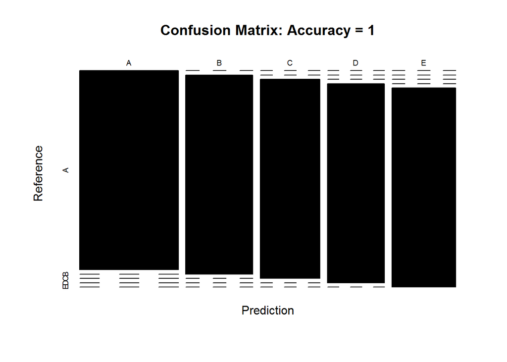

```r
plot(confMatrix2$table, col = confMatrix2$byClass, main = paste("Confusion Matrix: Accuracy =", round(confMatrix2$overall['Accuracy'], 4)))
```

##### Generalized Boosted Regression

```r
set.seed(10000)
GBR <- trainControl(method = "repeatedcv", number = 5, repeats = 1)
fitGBR <- train(classe ~ ., data=trainData, method = "gbm", trControl = GBR, verbose = FALSE)
fitGBR$finalModel
```

```
## A gradient boosted model with multinomial loss function.
## 150 iterations were performed.
## There were 52 predictors of which 52 had non-zero influence.
```

```r
gbmPred <- predict(fitGBR, newdata=testData)
confMatrix3 <- confusionMatrix(gbmPred, testData$classe)
confMatrix3
```

```
## Confusion Matrix and Statistics
##
##           Reference
## Prediction    A    B    C    D    E
##          A 1163   22    0    0    1
##          B   10  769   16    2    7
##          C    2    8  686   21    5
##          D    1    0    8  654    9
##          E    0    0    1    2  737
##
## Overall Statistics
##
##                Accuracy : 0.9721
##                  95% CI : (0.9666, 0.9769)
##     No Information Rate : 0.2852
##     P-Value [Acc > NIR] : < 2.2e-16
##
##                   Kappa : 0.9647
##  Mcnemar's Test P-Value : 0.0002605
##
## Statistics by Class:
##
##                      Class: A Class: B Class: C Class: D Class: E
## Sensitivity            0.9889   0.9625   0.9648   0.9632   0.9710
## Specificity            0.9922   0.9895   0.9895   0.9948   0.9991
## Pos Pred Value         0.9806   0.9565   0.9501   0.9732   0.9959
## Neg Pred Value         0.9956   0.9910   0.9927   0.9928   0.9935
## Prevalence             0.2852   0.1937   0.1724   0.1646   0.1840
## Detection Rate         0.2820   0.1865   0.1663   0.1586   0.1787
## Detection Prevalence   0.2876   0.1950   0.1751   0.1629   0.1794
## Balanced Accuracy      0.9906   0.9760   0.9771   0.9790   0.9851
```

```r
predictionFinal <- predict(modelfit2, validData, type = "class")
predictionFinal
```

```
##  1  2  3  4  5  6  7  8  9 10 11 12 13 14 15 16 17 18 19 20
##  B  A  B  A  A  E  D  B  A  A  B  C  B  A  E  E  A  B  B  B
## Levels: A B C D E
```